# Ayudantia 2 - Machine Learning

Nicolas Caraball

22/08/2024

# Introducción

Bienvenid@s a la segunda ayudantía de EAA3707 - Machine Learning para Negocios. En esta ocación vamos a ver los siguientes temas:

1. ¿Para qué necesitamos dividir los datos?
2. ¿Para qué necesitamos resamplear los datos?
3. Discusión: En que situaciones Overfitting es bueno.

## Antes de comenzar

Lo primero que debemos hacer siempre es cargar las librerias que utilizaremos durante nuestro proyecto. En esta caso vamos a cargar dos librerias que traen cargados datos. Primero gapminder la cual contiene un extracto de las bases de datos de [GAPMINDER](https://www.gapminder.org/data/), la cual tiene datos de multiples fuentes de distintas variables de paises. Entre estas se encuentran:

- Tasa de fertilidad total
- Tasa de mortalidad infantil
- PIB per cápita
- Índice de Gini
- Esperanza de Vida

Por otro lado vamos a cargar tseries la que nos permite descargar el valor de acciones de distintas empresas, siendo capaces de especificar la informacion que queremos (precio de inicio, precio de cierre, promedio, etc) y el intervalo de tiempo para el que lo queremos (cada dia, semana, mes).

```r
# Packetes para trabajar con datos
library(tidyverse)
library(tidymodels)

# Packetes con bases de datos
library(gapminder)
library(tseries)

# Seteamos un seed para poder reproducir resultados
set.seed(31415)
```

# ¿Para qué necesitamos dividir los datos?

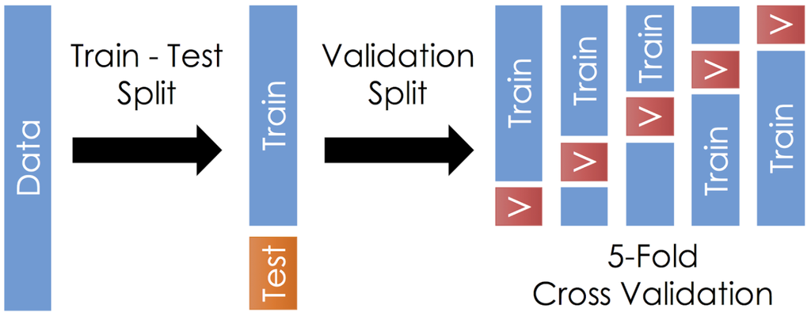

Proceso de separación de datos

En Machine Learning el analisis y modelamiento de los datos no terminar cuando ajustamos el modelo. Todo analisis tiene algún proposito, algo que queremos cumplir. Pero, ¿Como sabemos que tan bien lo hicimos?

Dentro de estos propositos hay dos en los que nos vamos a centar.

1. Predecir: Queremos poder predecir con precisión el comportamiento de una observación futura, como por ejemplo la probabilidad de no pago de un cliente, la probabilidad de deserción laboral, etc.
2. Relacionar: Queremos describir / formar relaciones entre los datos, por ejemplo, segmentos de clientes, recomendar videos, productos cocomprados, etc.

Para cumplir estos dos propositos existen muchos modelos distintos que podemos utilizar, los cuales dependiendo del tipo de variables que tenemos y las relaciones entre estas pueden ser mejores o peores. Por esta razón nos interesa buscar formas de poder comparar modelos y asi elegir el que mejor lo haga.

Ademas, no solamente existen muchos modelos, si no que estos pueden contar con muchos hiperparametros que cambian las caracteristicas y comportamiento del modelo. Por ejemplo, si queremos ajustar un modelo de regresión múltiple polinomial debemos elegir el grado que éste tendrá. En un modelo de K-Medias debemos elegir el numero de segmentos, etc.

## ¿Cuál es el problema entonces?

Muchos modelos se ajustan tratando de optimizar una funcion objetivo utilizando algun criterio de precisión, como puede ser el RMSE (Raiz Error Cuadratico Medio). En este caso, ¿hace sentido utilizar los mismos datos con los que entrenamos el modelo para medir que tan bueno es?

## ¿Cómo arreglamos esto?

Existen dos formas de poder solucionar este problema, una muy costosa pero mejor, y una practica pero levemente inferior:

1. Ajustar el modelo y esperar a conseguir más datos (por ejemplo seguir entregando creditos) y luego ver que tan bueno es el modelo en predecir. Esto puede ser muy costoso, tardar mucho tiempo y riesgoso, como con el caso de un estudio de una enfermedad.
2. Perder una parte de los datos totales que tenemos, y utilizar estos para ver que tan bueno es el modelo. Perdemos datos al momento de entrenar el modelo, pero tenemos la capacidad de evaluar el poder predictivo del modelo de forma más cercana a la realidad.

Basicamente todos los proyectos de Machine Learning parte con este proceso, separando los datos en una base de entrenamiento y una de test. La primera se ocupa para ajusta el modelo y la segunda para evaluar.

# Ejemplo Train - Test Spliting

Veamos un ejemplo utilizando la libreria gapminder. Supongamos que nos interesa estudiar la relación entre la esperanza de vida y el PIB de Chile. Primero que nada carguemos los datos y hagamos un grafico para explorar los datos.

```r
# Los datos están en el tibble gapminder
datosChile = gapminder %>% filter(country == "Chile")

# Veamos como se ven nuestros datos
head(datosChile)
```

```
## # A tibble: 6 × 6
##   country continent  year lifeExp      pop gdpPercap
##   <fct>   <fct>     <int>   <dbl>    <int>     <dbl>
## 1 Chile   Americas   1952    54.7  6377619     3940.
## 2 Chile   Americas   1957    56.1  7048426     4316.
## 3 Chile   Americas   1962    57.9  7961258     4519.
## 4 Chile   Americas   1967    60.5  8858908     5107.
## 5 Chile   Americas   1972    63.4  9717524     5494.
## 6 Chile   Americas   1977    67.1 10599793     4757.
```

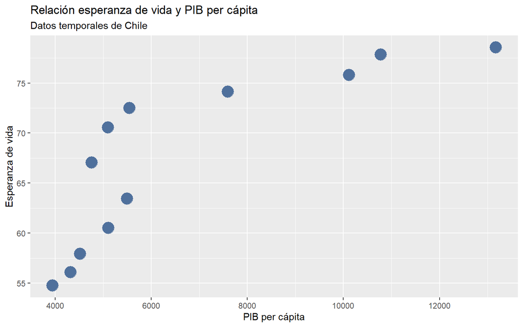

```r
# Creamos el grafico
ggplot(data = datosChile,
       aes(x = gdpPercap, y = lifeExp)) +
       geom_point(size = 6, color = '#4F709C') +
       labs(x = 'PIB per cápita', y = 'Esperanza de vida',
            title = 'Relación esperanza de vida y PIB per cápita',
            subtitle = 'Datos temporales de Chile')
```

Como podemos ver, pareciera que la relación entre estas dos variables no es lineal, por lo que podria ser mejor un modelo cuadratico / polinomial. Para ver el efecto de usar la misma base para entrenar y testear podemos ver en primer lugar como se ajusta el modelo segun el grado del polinomio:

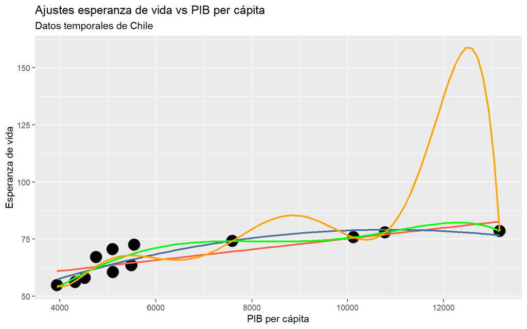

```r
ggplot(data = datosChile,
       mapping = aes(x = gdpPercap, y = lifeExp)) +
  geom_point(size = 6) +
  stat_smooth(method = 'lm', se = FALSE, col = 'tomato',
              formula = y ~ x) +
  stat_smooth(method = 'lm', se = FALSE, col = '#4F709C',
              formula = y ~ poly(x, 2, raw = TRUE)) +
  stat_smooth(method = 'lm', se = FALSE, col = 'green',
              formula = y ~ poly(x, 5, raw = TRUE)) +
  stat_smooth(method = 'lm', se = FALSE, col = 'orange',
              formula = y ~ poly(x, 7, raw = TRUE)) +
  labs(x = 'PIB per cápita', y = 'Esperanza de vida',
       title = 'Ajustes esperanza de vida vs PIB per cápita',
       subtitle = 'Datos temporales de Chile')
```

Como podemos ver, mientras mayor el grado del polinomio, el modelo se asemeja cada vez más a los datos. Esto es lo que se denomina un problema de overfitting. En este caso estamos haciendo que el modelo no solo explique la variabilidad real de la asociación si no que tambien el ruido inherente.

Para comparar numericamente los modelos, estimemoslos y veamos como se comporta el RMSE segun el grado del polinomio.

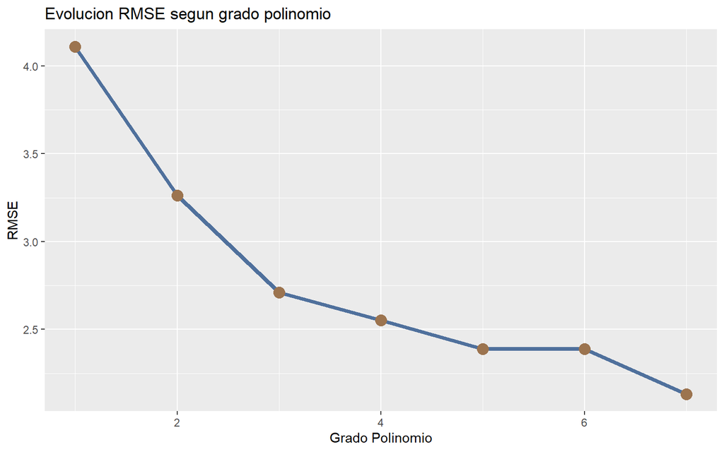

```r
# Definimos el vector donde vamos a guardar los RMSE y el grado del polinomio
vectorRMSE = c()
vectorGrado = c()

for (i in 1:7) {
  # Ajustamos el modelo de regresion lineal del grado i
  lm = lm(lifeExp ~ poly(gdpPercap, i), datosChile)

  # Obtenemos su RMSE
  RMSE = mean(sqrt(lm$residuals^2))

  # Agregamos los valores a los vectores
  vectorRMSE = append(vectorRMSE, RMSE)
  vectorGrado = append(vectorGrado, i)
}

# Guardemos los resultados en un tibble
tibbleRMSE = tibble(grado_pol = vectorGrado,
                   RMSE = vectorRMSE)

ggplot(tibbleRMSE, aes(x = grado_pol, y = RMSE)) +
        geom_line(color = "#4F709C",
                  lwd = 1.5) +
        geom_point(color = "#9c744f",
                  size = 4) +
        labs(x = "Grado Polinomio",
            title = "Evolucion RMSE segun grado polinomio")
```

Podriamos pensar, Bacan! Nuestro modelo claramente es mejor, ya que el RMSE disminuye… pero, ¿Es verdaderamente asi?

Una vez que hayamos hecho el split, haremos lo mismo solo que calcularemos el ECM usando la base de testeo.

Nota: Siempre que vayan a trabajar con un paquete puede ser util que vean la documentacion / pagina de este. (La mayoria de las librerias lo tienen). En este caso, la pagina es [esta](https://rsample.tidymodels.org/index.html).

```r
# Hacemos la separación de los datos
initialSplit = initial_split(datosChile)
initialSplit
```

```
## <Training/Testing/Total>
## <9/3/12>
```

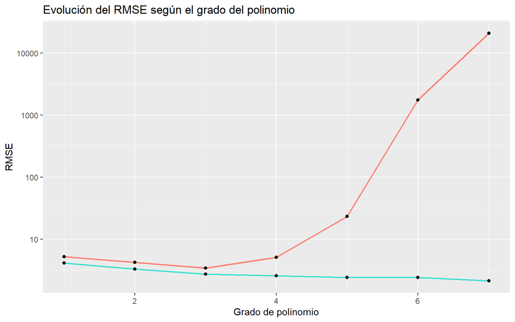

```r
# Extraigamos los datos
datosTrain = training(initialSplit)
datosTest = testing(initialSplit)

# Definimos el vector donde vamos a guardar los RMSE
vectorRMSETest = c()

for (i in 1:7) {
  # Ajustamos el modelo de regresión lineal de grado i
  lm = lm(lifeExp ~ poly(gdpPercap, i), datosTrain)

  # Veamos el RMSE
  prediccion = predict(lm, datosTest)
  RMSE = mean(sqrt((datosTest$lifeExp - prediccion)^2))

  # Guardemoslo en el vector
  vectorRMSETest = append(vectorRMSETest, RMSE)
}

# Agreguemoslo a nuestro tibble anterior
tibbleRMSE = mutate(tibbleRMSE, RMSETest = vectorRMSETest)

# Grafiquemos ambos RMSE en un mismo grafico
ggplot(tibbleRMSE, aes(x=grado_pol)) +
  geom_line(aes(y = RMSE), col = "turquoise", lwd = 0.8) +
  geom_point(aes(y = RMSE)) +
  geom_line(aes(y = RMSETest), col = "salmon", lwd = 0.8) +
  geom_point(aes(y = RMSETest)) +
  scale_y_log10() +
  labs(x = 'Grado de polinomio',
       title = 'Evolución del RMSE según el grado del polinomio')
```

El no estar separando los datos en un set de entrenamiento y uno de testeo estaba haciendo que hicieramos un modelo pesimo! Es importante asegurarnos que nuestro modelo sea bueno en la vida real. En este caso pareciera que la mejor prediccion lo da un modelo de menor grado polinomial.

# ¿Por qué necesitamos resamplear los datos?

La idea basica de hacer resampling a los datos de entrenamiento se basa en tratar de conseguir mejores estimadores / hiperparametros. En particular, nos interesan metodos que nos permitan obtener métricas que sean buenos estimadores del valor que se obtendira al obtener nuevos datos.

Tambien esto se puede pensar de la siguiente forma, dado que los datos con los que trabajamos deberian ser representativos, el tomar estas muestras nos permite ver como se comportaran con nuevos datos y asi conseguir por ejemplo intervalos de confianza para los estimadores, errores, etc.

Lo anterior se conoce como métodos de resampling, los cuales son aplicados a la base de entrenamiento, para asi poder elegir el modelo óptimo que finalmente será puesto a prueba con la base de test. Entre los métodos que vimos en clases se encuentran:”

1. K-Fold Cross-Validation
2. Leave-one-out Cross-Validation: K-Fold donde K=n.
3. Monte Carlo Cross-Validation
4. Bootstrap

Comunmente los más utilizado con K-Fold y Bootstrap. Donde K-Fold tiende a tener menos sesgo y más varianza, mientras que Bootstrap tiende a tenes más sesgo pero menos varianza. ¿Cuál preferimos?.

# Ejemplo Resampling.

Para ver un ejemplo de la aplicación de métodos de remuestreo, utilizaremos informacion del precio de acciones de tres compañias chilenas: BCI, Banco de Chile y Banco Santander. Para esto vamos a utilizar la libreria tseries para conseguir los precios de cierre ajustados mensuales de estas tres empresas desde el 2008 al dia de hoy.

```r
# Definimos nuestras empresas de interes
empresas = c("BCI.SN", "BCH", "BSAC")

for (i in 1:length(empresas)) {
  infoBanco = get.hist.quote(instrument = empresas[i],
                             start = '2008-02-01',
                             quote = 'AdjClose',
                             compression = 'm') %>% as_tibble()
  if (i == 1) {
    datosBancos = tibble(infoBanco)
  }
  else {
    datosBancos = cbind(datosBancos, infoBanco)
  }
}

names(datosBancos) = c("BCI", "BancoChile", "Santander")
```

```r
head(datosBancos)
```

```
##        BCI BancoChile Santander
## 1 6532.444   7.897768  9.370088
## 2 6902.616   7.424489  9.460603
## 3 6619.543   7.753816  9.507672
## 4 6162.272   7.643283  9.899932
## 5 6140.498   6.752980  8.188388
## 6 5748.551   6.777207  8.700517
```

Ahora que ya tenemos los datos cargados, podemos ver en un grafico como se comportan por ejemplo de manera conjunta el precio del banco BCI y el Banco de Chile a través del tiempo:

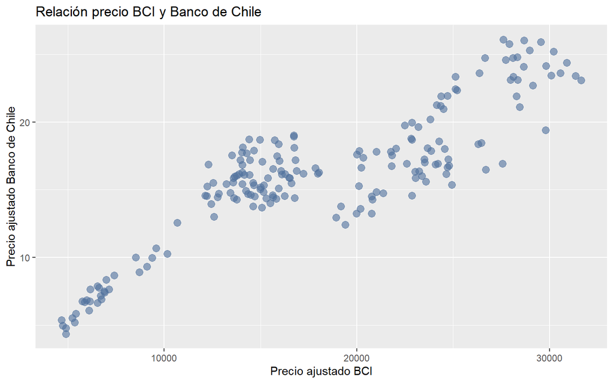

Pareciera que existe una relación positiva entre los precios de las acciones de estas empresas, lo que hace sentido.

Supongamos que queremos ajustar un modelo de regresión LASSO. Este modelo es similar a una regresión lineal normal, aunque le agrega un factor de penalización $\lambda$. Recordemos, el modelo de regresion simple trata de minimizar la suma de errores cuadrados (MSE), esto es:

$$\sum_{i=1}^n (y_i - \beta_0 - \beta_1 x_{1, i})^2$$
Ahora, el modelo LASSO desea encontrar valores de los $\beta$ que minimicen:
$$\sum_{i=1}^n (y_i - \beta_0 - \beta_1 x_{1, i})^2 + \lambda \sum_{j=0}^1
|\beta_j|$$

Esto lo que hace es que el modelo trate de conseguir valores de beta que no sean muy grandes, y divertidamente, logra hacer el proceso de seleccion de variables por si mismo (y no tiene problemas con variables colineales!!)

Aqui tenemos un modelo con un hiperparametro, lambda no es un parametro que el modelo en si estime, si no que debemos darle un valor antes de ajustar nuestro modelo. Más adelante vamos a ver bien como hacemos para elegir hiperparametros optimos, asi que confien en el codigo que viene.

Vamos a generar un intervalo de confianza para el error de estimacion segun el parametro $\lambda$. Primero vamos a trabajar con K-Folds con K = 10.

```r
# Separamos los datos
splitPrecios = initial_split(datosBancos)
bancosTrain = training(splitPrecios)
bancosTest = testing(splitPrecios)

# Generamos los folds
bancosFolds = vfold_cv(bancosTrain)

# Generamos la receta
bancosRecipe = recipe(BCI ~ ., data = bancosTrain) %>%
               step_zv(all_numeric(), -all_outcomes()) %>%
               step_normalize(all_numeric(), -all_outcomes())

# Generamos el modelo
bancosModel = linear_reg(penalty = tune(), mixture = 1) %>%
              set_engine('glmnet')

# Generamos la grilla de valores para lambda
gridLambda = grid_regular(penalty(range = c(-1, 5)),
                          levels = 50)

# Agregamos receta. (No agregamos el modelo)
workflowBancos = workflow() %>%
                 add_recipe(bancosRecipe) %>%
                 add_model(bancosModel)


lambdaGrid = tune_grid(workflowBancos,
                       resamples = bancosFolds,
                       grid = gridLambda)

lambdaGrid %>% collect_metrics()
```

```
## # A tibble: 100 × 7
##    penalty .metric .estimator     mean     n  std_err .config
##      <dbl> <chr>   <chr>         <dbl> <int>    <dbl> <chr>
##  1   0.1   rmse    standard   3402.       10 163.     Preprocessor1_Model01
##  2   0.1   rsq     standard      0.720    10   0.0624 Preprocessor1_Model01
##  3   0.133 rmse    standard   3402.       10 163.     Preprocessor1_Model02
##  4   0.133 rsq     standard      0.720    10   0.0624 Preprocessor1_Model02
##  5   0.176 rmse    standard   3402.       10 163.     Preprocessor1_Model03
##  6   0.176 rsq     standard      0.720    10   0.0624 Preprocessor1_Model03
##  7   0.233 rmse    standard   3402.       10 163.     Preprocessor1_Model04
##  8   0.233 rsq     standard      0.720    10   0.0624 Preprocessor1_Model04
##  9   0.309 rmse    standard   3402.       10 163.     Preprocessor1_Model05
## 10   0.309 rsq     standard      0.720    10   0.0624 Preprocessor1_Model05
## # ℹ 90 more rows
```

Ahora que ajustamos el modelo podemos ver la evolucion del RMSE en el siguiente grafico.

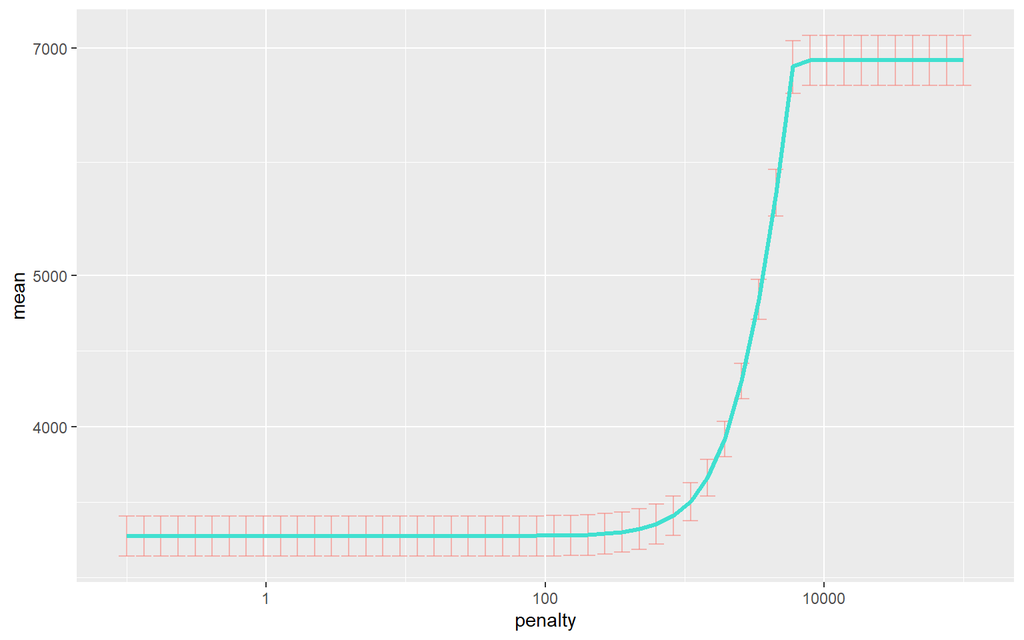

Hagamos lo mismo pero cambiando el metodo de resampling a bootstrap

```r
# Generamos el resample
bancoBootstrap = bootstraps(bancosTrain)

# Tuneamos con grid
lambdaGrid = tune_grid(workflowBancos,
                        resamples = bancoBootstrap,
                        grid = gridLambda)

lambdaGrid %>% collect_metrics()
```

```
## # A tibble: 100 × 7
##    penalty .metric .estimator     mean     n  std_err .config
##      <dbl> <chr>   <chr>         <dbl> <int>    <dbl> <chr>
##  1   0.1   rmse    standard   3409.       25 44.1     Preprocessor1_Model01
##  2   0.1   rsq     standard      0.755    25  0.00859 Preprocessor1_Model01
##  3   0.133 rmse    standard   3409.       25 44.1     Preprocessor1_Model02
##  4   0.133 rsq     standard      0.755    25  0.00859 Preprocessor1_Model02
##  5   0.176 rmse    standard   3409.       25 44.1     Preprocessor1_Model03
##  6   0.176 rsq     standard      0.755    25  0.00859 Preprocessor1_Model03
##  7   0.233 rmse    standard   3409.       25 44.1     Preprocessor1_Model04
##  8   0.233 rsq     standard      0.755    25  0.00859 Preprocessor1_Model04
##  9   0.309 rmse    standard   3409.       25 44.1     Preprocessor1_Model05
## 10   0.309 rsq     standard      0.755    25  0.00859 Preprocessor1_Model05
## # ℹ 90 more rows
```

Ahora si graficamos el RMSE promedio segun el penalty vamosa ver lo siguiente:

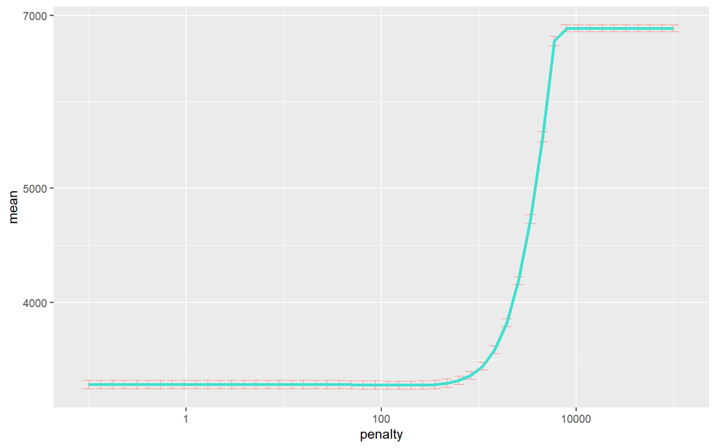

```r
lambdaGrid %>%
  collect_metrics() %>%
  filter(.metric == 'rmse') %>%
  ggplot(aes(x = penalty, y = mean, color = .metric)) +
  geom_errorbar(aes(
    ymin = mean - (1.96 * std_err / sqrt(10)),
    ymax = mean + (1.96 * std_err / sqrt(10))
  ), alpha = 0.5) +
  geom_line(linewidth = 1.2, color = "turquoise") +
  scale_y_log10() +
  scale_x_log10() +
  theme(legend.position = "none")
```

Como podemos ver, se cumple que K-Folds tiene menos sesgo pero mayor varianza, mientras que Bootstrap tiene más sesgo y menor varianza.

# ¿Discusión: Cuando overfitting es bueno?